# E-commerce Sequential Testing A/B Test Code

**Goal:** This notebook can help A/B Test practitioners plan for and execute experiments using Google Analytics 4 data. It transforms GA4 e-commerce event data into an experiment ready table where activity can be aggregated cumulatively for any date range.

Data in this form allows analysts to run useful pre-experiment analyses, including reviewing:

1. historical daily metric activity data,
2. cumulative mean and variance over time,
3. expected error decay over time,
4. samples size requirements by metric,
5. metric distibutions for normality and skew,
6. expected pvalues over time,
7. and many other useful pre-experiment metrics.

Section X allows analysts to select a specific metric and repeatedly re-group visitors to test different experiment evaluation techniques. This section highlights some issues with underpowered tests on high variance, low frequency metrics like purchase count. Finally, Section XI reviews sequential testing methods that mitigate some problems associated with underpowered tests and false positives.

**Sequential testing aside, this notebook illustrates the importance of choosing a single experiment metric, re-testing p-values above .01, and using 99% confidence intervals for websites performing many experiments as suggested by practitioners like Ron Kohavi. Moreover, analysts should make sure stakeholders understand uncertainty reflected in confidence intervals and what they mean about impact estimates. Knowing this will helps stakeholders decide how certain they need to be given costs of implementing changes.**

Since no actual experiment was run, the code selects an arbitrary evaluation page and aggregates user activity post evaluation page visit to the end of a selected experiment period. Inputs are variables. They can easily be changed to run code on any page or set of events for any period.

Metrics evaluated are: **purchase**, **purchase quantity**, **purchase bookings**, **engagement minutes**, **daily unique page visits**, **scroll**, **view_item**, **view_promotion**, **add_to_cart**, **begin_checkout**, **select_item**, and **select_promotion**.

**Sections:**

I. Connect ot Big Query

II. Query Data for Analysis - SQL Cross Join Method

III. Historical Metric Activity Review

IV. Cumulative Statistics Over Time

V. Sample Size Calculations

VI. Create Experiment Groups

VII. Review Metric Distributions

VIII. Maximum Sample Size Calculation

IX. Experiment Metrics Calculation

X. Single Metric Repeated Draws ~ T-Test P-Value Over Time

XI. Appendix - Sequential Testing Methods

**Note:** Event data can be wonky. This code assumes events operate as expected. Its best practice to check prior to relying on them. For example, the code drops purchase events with null values for bookings. This should be checked. For future iterations of this code, it might be desireable to add null value counts or drop counts for each event parameter.

**Data Source:** https://developers.google.com/analytics/bigquery/web-ecommerce-demo-dataset

**References:**

1. https://www.evanmiller.org/sequential-ab-testing.html
2. https://docs.geteppo.com/statistics/confidence-intervals/statistical-nitty-gritty
3. https://docs.growthbook.io/statistics/sequential
4. https://booking.ai/sequential-testing-at-booking-com-650954a569c7
5. https://engineering.atspotify.com/2023/03/choosing-sequential-testing-framework-comparisons-and-discussions/
6. https://books.google.no/books?id=qBrpTcAYtNQC&printsec=frontcover&hl=no&source=gbs_ge_summary_r&cad=0#v=onepage&q&f=false
7. Statistical Methods in Online A/B Testing (Georgiev)
8. Group Sequential Methods with Applications to Clinical Trials (Turnbull et al.)
9. Group Sequential Designs: A Tutorial (Lakens et al.)
10. https://www.rpact.org/vignettes/getting-started/rpact_step-by-step_tutorial/
11. https://online.stat.psu.edu/stat509/lesson/9/9.6
12. https://netflixtechblog.com/improving-experimentation-efficiency-at-netflix-with-meta-analysis-and-optimal-stopping-d8ec290ae5be

**HTML:** jupyter nbconvert --no-input --to html AB_Test_Code_Sequential_Testing_SHARE.ipynb

# I. Set Up Connection to Big Query Using Service Account Key

# II. Query Data for Analysis - SQL Cross Join Method

## A. BIG QUERY ENGAGEMENT EVENTS MEANINGS

1. **page_view:** Each time the page loads or the browser history state is changed by the active site. In this analysis, **unique_pages** calculates the number of unique urls visited per day.

*Properties*

- page_title,
- page_location (page URL),
- page_referrer (previous page URL),
- engagement_time_msec
- session_engaged: An engaged session is a session that lasts longer than 10 seconds, has a conversion event, or has at least 2 pageviews or screenviews. Note: Bounce rate is the % of sesssions that were not engaged.
2. **scroll:** This triggers when a visitor scrolls down the page of interest.
3. **user_engagement:** When the app is in the foreground or webpage is in focus for at least one second. In this analysis, **engage_mins** aggregates this time in minutes.
- engagement_time_msec
4. **click:** Each time a user clicks a link that leads away from the current domain.

*Properties*

- link_classes
- link_domain
- link_id
- link_url

#### B. ITEM BASED ECOMMERCE EVENTS

*Property Structure Example:*

gtag("event", "begin_checkout", {

**currency:** "USD",

**value:** 7.77,

**coupon:** "SUMMER_FUN",

**items:** [{**item_id:** "SKU_12345", **item_name:** "Stan and Friends Tee", **affiliation:** "Google Merchandise Store", **coupon:** "SUMMER_FUN", **discount:** 2.22, **index:** 0, **item_brand:** "Google", **item_category:** "Apparel",**item_category2:** "Adult", **item_category3:** "Shirts", **item_category4:** "Crew", **item_category5:** "Short sleeve", **item_list_id:** "related_products", **item_list_name:** "Related Products", **item_variant:** "green", **location_id:** "ChIJIQBpAG2ahYAR_6128GcTUEo", **price:** 9.99, **quantity:** 1}]

});

5. **view_promotion:** This event signifies a promotion was viewed from a list.
6. **view_item:** This event signifies that some content was shown to the user. Use this event to discover the most popular items viewed.
7. **select_promotion:** This event signifies a promotion was selected from a list.
8. **add_to_cart:** This event signifies that an item was added to a cart for purchase.
9. **select_item:** This event signifies an item was selected from a list.
10. **begin_checkout:** This event signifies that a user has begun a checkout.
11. **purchase:** This event signifies when one or more items is purchased by a user.
12. **purchase_bookings:** This event signifies revenue from items purchased by a user.
13. **purchase_quantity:** This event signifies when one or more items is purchased by a user.

**Sources:**

- https://support.google.com/analytics/answer/9234069?sjid=15108255341621745705-NA
- https://developers.google.com/analytics/bigquery/basic-queries
- https://developers.google.com/analytics/devguides/collection/ga4/ecommerce?client_type=gtag
- https://support.google.com/analytics/answer/9143382
- https://developers.google.com/analytics/devguides/collection/ga4/reference/events?client_type=gtag
- https://support.google.com/analytics/answer/11109416?hl=en
- https://support.google.com/analytics/answer/6367342#zippy=%2Cin-this-article
- https://www.ga4bigquery.com/sessions-dimensions-metrics-ga4/
- https://support.google.com/analytics/answer/9037342?hl=en&ref_topic=9359001&sjid=8478716955813495246-NA#zippy=%2Cin-this-article

**Analysis Notes:** A lot of Google Analytics 4 dimensions and metrics can be derived straight from the tables without performing calculations on the data. With the help of unnest and parse for dates or timestamps we can do the trick.

## B. SQL QUERY

**Pre-Period:** 11/01/2020 - 12/14/2020

**Evaluation Period (ie Fake Experiment):** 12/01/2020 - 12/14/2020

**Evaluation Page:** 'Apparel | Google Merchandise Store'

**Data Source:** https://developers.google.com/analytics/bigquery/web-ecommerce-demo-dataset

**Step 1:** SQL query attributes visitor web event activity to occurance date so it can be aggregated over any period desired. Like in a real experiment, this code focuses on event activity accruing after a users first visit to the selected evaluation page.

**Technical Note:** The code uses evaluation page timestamps to deduplicate event activity following a cross join on evaluation page views.

**Note:** 9511 unique visitors expected over the period from 12/1 to 12/14. 8070 only visited eval page once.

```
Downloading: 100%|█████████████████████████████████████████████████████████████|
```

**Code Notes:** SQL aggregates post evaluation page visit user event activity to the user id and daily level. It includes counts of events triggered post evaluation page visit and common calculated metrics. This allows us to estimate expected confidence intervals for metrics as the proposed experiment evolves. It also allows for the calculation of expected p-values over time. It should also allow for user level sequential testing like in Optimizely.

**Bounce Definition:** Rather than defining a user as bounced if the user failed to trigger at least one of the following events: **'purchase', 'scroll', 'view_item', 'view_promotion', 'add_to_cart' , 'begin_checkout', 'select_item', or 'select_promotion'** post eval page visit. Now, the calculated engage_time event will be used to determine whether a user bounced. I confirmed that the addition of new calculated events did not impact the original events. The code can be returned to its original state by replacing combined_events_table with events_table in bucketed_event_table CTE and unhashing **or event.event_ts is null**.

**Step 2:** Convert timestamps to pandas datetime objects.

**Step 3:** For most events the number of times they triggered was used to measure user engagement, however, user level bookings, purchase quantities, engagement(mins), and unique daily page visits come from event properties and had to be calculated seperately. **Since the calculated metrics were in a different column from the triggered event counts, they need to be coalesced into one column.**

**Step 4:** Check table output.

|  | first_exposure_ts | user_pseudo_id | metric_date | adj_event_name | final_metric_value |
| --- | --- | --- | --- | --- | --- |
| 75405 | 2020-12-07 07:30:27.529526+00:00 | 6822684.1627482502 | 2020-12-07 | purchase_quantity | 11.0 |
| 75406 | 2020-12-02 21:17:16.538719+00:00 | 76370387.0865247378 | 2020-12-11 | purchase_quantity | 10.0 |
| 75407 | 2020-11-15 20:48:37.715274+00:00 | 1457551.9813423359 | 2020-11-16 | purchase_quantity | 14.0 |
| 75408 | 2020-11-19 09:57:06.135364+00:00 | 3041494.0908353891 | 2020-11-20 | purchase_quantity | 6.0 |
| 75409 | 2020-12-05 09:30:48.260210+00:00 | 22641180.4696400962 | 2020-12-07 | purchase_quantity | 2.0 |

**Table A Description:** Table is unique at the user id, event_name, and metric date level. **first_exposure_timestamp** represents the user's first visit to the evaluation page during the selected date range. **metric_date** tracks the date events were triggered. **final_metric_value** is the visitors's daily count for the referenced event. For example, a final_metric_value of 2 on 12/01/2020 for user 123 means the user triggered the event 2 times on that date. **Note:** Calculated events follow similar logic but aggregate metric value like bookings or unique urls visited rather than event occurences.

**Note:** Tiggered events for unique_pages event is total times page event fired.

**ERROR FIX NEEDED: I need to seperately query the pre period and fake experiment date range to get proper first_exposure timestamp.**

# III. Historical Metric Activity Review

**ERROR FIX:** 1) Grouping by metric_date does actually get me daily evaluation page traffic. **FIXED** 2) Add daily average.

## A. Historical Daily New Evaluation Page Visitors Plot

**Goal:** Plot daily new evaluation page (aka proposed experiment page) visitors. This helps analysts get a sense of daily expected traffic to the experiment page and estimate duration based on sample size requirements.

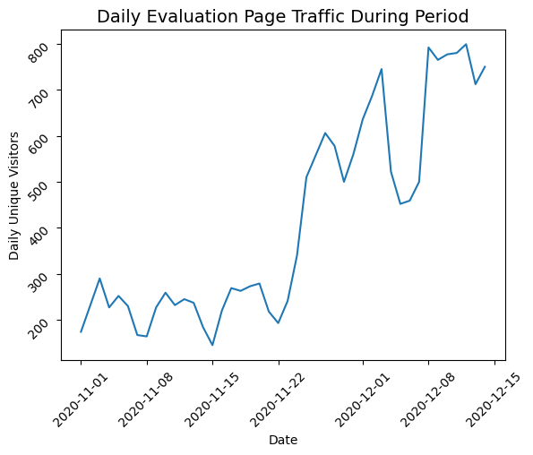

**Conclusions:**

a) The plot shows that daily page traffic jumped substantially between November and December.

b) In this case, the only pre-evaluation data available was from November 2020. As a rule of thumb, we should not run experiments or estimate experiment traffic from holidays or sale months like black friday unless central to what is being tested.

**Notes:** There are many ways to estimate page traffic for experiment duration based on sample size calculations. If you have fairly stable traffic, a fairly naive method involves simply taking the last month while avoiding months with holidays or unusual activity. Alternatively, we can get a pretty good idea of expected conversion rates by taking the rate of growth YoY of the prior month times the last years estimate for the experiment's month. Either way, its helpful to review at least 14 months to two years of time series data to see if estimates are historically reasonable.

## B. Historical Metric Activity Plots - Post Evaluation Page Event Activity

**Goal:** This section plots total triggered events by visitors who previously visited the evaluation page. This helps analysts assess the functionality of events over time. To improve plot readability, metrics have been seperated into high, medium, and low frequency groups based on average daily values during the period and plotted seperately.

**Step 1:** Sum evaluated metrics by date across all visitors.

**Step 2:** Calculate average for metric across all days present. This allows analysts to group events by their expected daily frequency. For example, select_promotion and purchase are grouped together as very low frequency metrics.

|  | adj_event_name | period_daily_average |
| --- | --- | --- |
| 8 | select_promotion | 7.659 |
| 3 | purchase | 22.705 |
| 5 | purchase_quantity | 104.182 |
| 1 | begin_checkout | 137.500 |
| 7 | select_item | 158.591 |
| 11 | view_promotion | 279.000 |
| 0 | add_to_cart | 300.400 |
| 6 | scroll | 1089.773 |
| 2 | engage_mins | 1523.143 |
| 4 | purchase_bookings | 1872.341 |
| 10 | view_item | 2180.227 |
| 9 | unique_pages | 3908.795 |

**Table B Description:** This table averages daily total metric activity across all days to review expected metric frequency per day.

**Step 3:** Create frequency groups using daily averages.

**High Activity:** Metrics with daily averages above 1000.

**Medium Activity:** Metrics with daily averages between 100 and 1000.

**Low Activity:** Metrics with daily averages below 100.

### i. Aggregated Daily Activity by Metric Plot

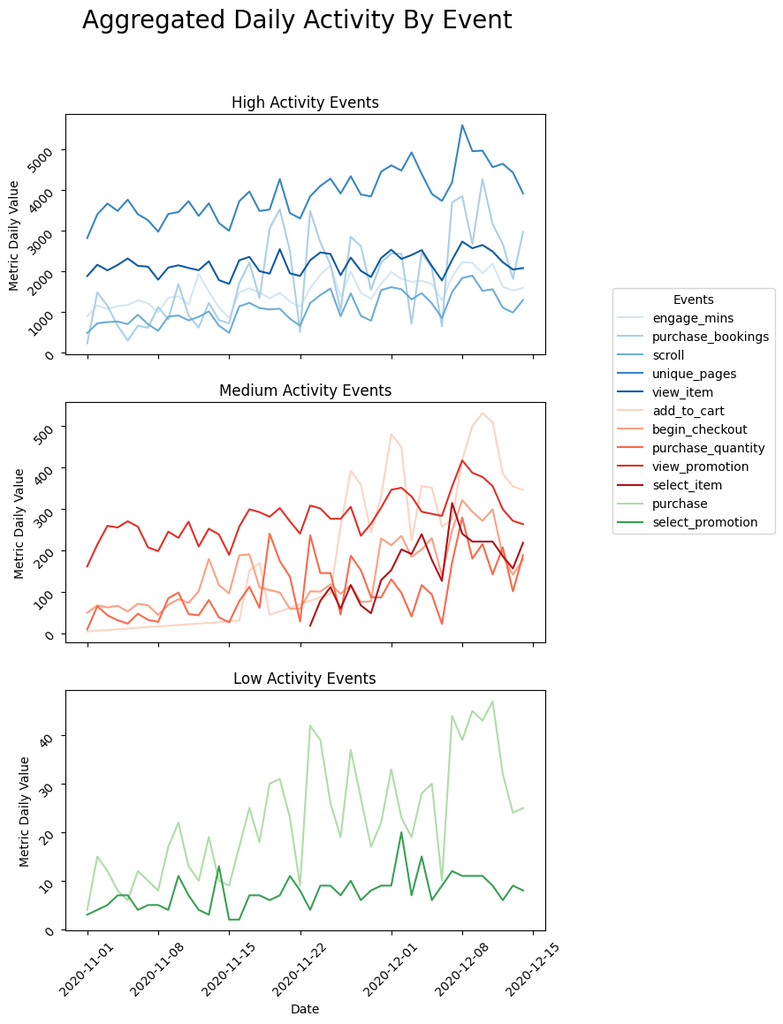

**Conclusion:** Most metrics appear fairly consistent across time. However, **select_item** and **add_to_cart** appear broken. For example, select_item is missing data for most of the pre period and add to cart does not match purchase activity. If this were a real experiment, they would be removed from consideration as a metric and data engineering would be notified.

# IV. Cumulative Statistics over Time

**Goal:** For many experiments, user level experiment metrics accrued after exposure are calculated over the entire experiment period. For good websites attracting lots of repeat active users, metric variance will likely increase over time because visitors exposed early have more time to accrue metrics.

To mimic this, the section:

1. Visualizes how metric means and variance accrue over time.
2. Visualizes how 95% Wald confidence intervals as a percent of mean estimates for each metric decay over time. This helps stakeholders consider expected error ranges over time.

**Note:** 1) Since visitors are randomly bucketed into treatment/control groups in real time, groups should have similar numbers of early and late participants. 2) Analysts can discuss with stakeholders the pros and cons of reducing variance by evaluating metrics accrued within a specified window of hitting the experiment page. However, this strategy may miss indicators of longer term impacts from changes.

## A. Calculate Cumulative Summary Statistics over Time Using For Loop

1. The **first for loop** creates a dataframe with all unique experiment participant **user ids** appearing on(or before) the reference date (i) and assigns a 0 to each user_id in a column called **post_count**.
2. The **second for loop** creates a dataframe with **user_id** and triggered_events counts as **post_count** for each **adj_event_name(j) in event_array** on(or before) the reference date (i).
3. **User Level Aggregation**: The dataframe from the first loop is concatinated with the dataframe from the second and **post_count is summed to the user level.** Note: Summing drops 0 values for users that triggered the selected event but keeps those who did not.
4. Calculate Statistics

**Step 1:** Create a list of events and desired dates for evaluation. The code evaluates the pre-experiment period from 11/01/2020 to 11/30/2020.

```
[Timestamp('2020-11-06 00:00:00'),
 Timestamp('2020-11-30 00:00:00'),
 Timestamp('2020-11-02 00:00:00'),
 Timestamp('2020-11-04 00:00:00'),
 Timestamp('2020-11-20 00:00:00')]
```

**Step 2:** Run for loop calculating statistics accrued on(or before) each include reference date.

**Step 3:** Create daily accrued statistics table for each event, calculate days since period start, and Wald 95% confidence intervals as a percent of mean estimates over time.

**Step 4:** Seperate events into groupings based on average daily frequency.

**Step 5:** Create a dataframe including cumulative stats from the end of the period. This allows analysts to annotate plots with final values and is used for required sample size estimates.

|  | count | mean | std | min | 25% | 50% | 75% | max | reference_date | event_name | SE | CI | CI_Percent | Days_Since_Start |
| --- | --- | --- | --- | --- | --- | --- | --- | --- | --- | --- | --- | --- | --- | --- |
| post_count | 8873.000 | 0.864 | 1.798 | 0.000 | 0.000 | 0.000 | 1.000 | 19.000 | 2020-11-30 | view_promotion | 0.038 | 0.075 | 8.664 | 30.000 |
| post_count | 8873.000 | 7.124 | 16.288 | 0.000 | 0.000 | 0.000 | 4.000 | 222.000 | 2020-11-30 | view_item | 0.346 | 0.678 | 9.515 | 30.000 |
| post_count | 8873.000 | 12.261 | 25.944 | 1.000 | 1.000 | 2.000 | 7.000 | 170.000 | 2020-11-30 | unique_pages | 0.551 | 1.080 | 8.806 | 30.000 |
| post_count | 8873.000 | 0.022 | 0.179 | 0.000 | 0.000 | 0.000 | 0.000 | 5.000 | 2020-11-30 | select_promotion | 0.004 | 0.007 | 34.039 | 30.000 |
| post_count | 8873.000 | 0.070 | 0.533 | 0.000 | 0.000 | 0.000 | 0.000 | 13.000 | 2020-11-30 | select_item | 0.011 | 0.022 | 31.481 | 30.000 |
| post_count | 8873.000 | 3.182 | 7.044 | 0.000 | 0.000 | 1.000 | 3.000 | 123.000 | 2020-11-30 | scroll | 0.150 | 0.293 | 9.214 | 30.000 |
| post_count | 8873.000 | 0.293 | 2.547 | 0.000 | 0.000 | 0.000 | 0.000 | 140.000 | 2020-11-30 | purchase_quantity | 0.054 | 0.106 | 36.134 | 30.000 |
| post_count | 8873.000 | 5.244 | 36.139 | 0.000 | 0.000 | 0.000 | 0.000 | 904.000 | 2020-11-30 | purchase_bookings | 0.767 | 1.504 | 28.677 | 30.000 |
| post_count | 8873.000 | 0.063 | 0.322 | 0.000 | 0.000 | 0.000 | 0.000 | 6.000 | 2020-11-30 | purchase | 0.007 | 0.013 | 21.371 | 30.000 |
| post_count | 8873.000 | 4.683 | 12.472 | 0.000 | 0.137 | 1.046 | 5.260 | 877.500 | 2020-11-30 | engage_mins | 0.265 | 0.519 | 11.084 | 30.000 |
| post_count | 8873.000 | 0.328 | 1.138 | 0.000 | 0.000 | 0.000 | 0.000 | 26.000 | 2020-11-30 | begin_checkout | 0.024 | 0.047 | 14.434 | 30.000 |
| post_count | 8873.000 | 0.234 | 1.520 | 0.000 | 0.000 | 0.000 | 0.000 | 43.000 | 2020-11-30 | add_to_cart | 0.032 | 0.063 | 27.055 | 30.000 |

**Table C Description:** The table provides per visitor cumlative summary statistics for metrics accrued after visiting the evaluation page during a 30 day period. **Mean** and **Standard Deviation(std)** are at the user level. **Count** is the number of visitors exposed to the experiment. **SE** represents Welch's standard error. **CI_Percent** is the percent error for mean estimates based on confidence intervals. For example, the view_promotion confidence interval was +/- 8% after 30 days.

**Conclusions:**

a) The quantiles suggest that most values are zero inflated. This means most visitors do not trigger the metrics.

b) Although not done here, the distance of max values from the 75% quantiles help us determine whether outliers may be a problem. We would want to determine what these large numbers represent. Capping values at the 99.9% is commonly done to reduce variance and shorten experiment duration.

c) Since the confidence interval decays faster, if user purchases are the metric of interest, it might be worth considering the use of begin checkout rather than purchase bookings or quantity.

**Notes:**

1. Estimated 95% Two Sided Confidence Intervals were calculated using Welch's Standard Error.

SE = $\sqrt{\frac{S_T^2}{n_T}+\frac{S_C^2}{n_C}} * 1.97$

## B. Cumulative Mean over Time Plot

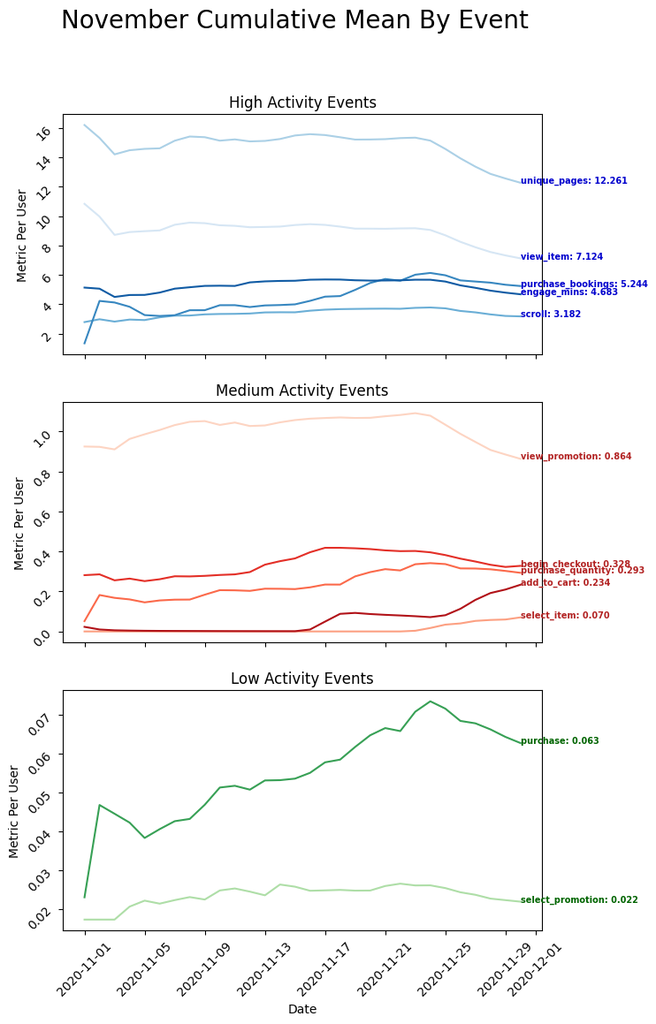

**Conclusion:**

a) **add_to_cart** and **select_item** are clearly behaving strangely as expected.

b) Most metrics appear fairly stable over time except purchase metrics. A mean that moves around a lot is likely a high variance event and will take longer to estimate.

c) Metrics with very small per user averages and high variance like purchase (orders) require very large sample sizes to estimate and may be impractical depending on site traffic.

## C. Cumulative Standard Deviation over Time Plot

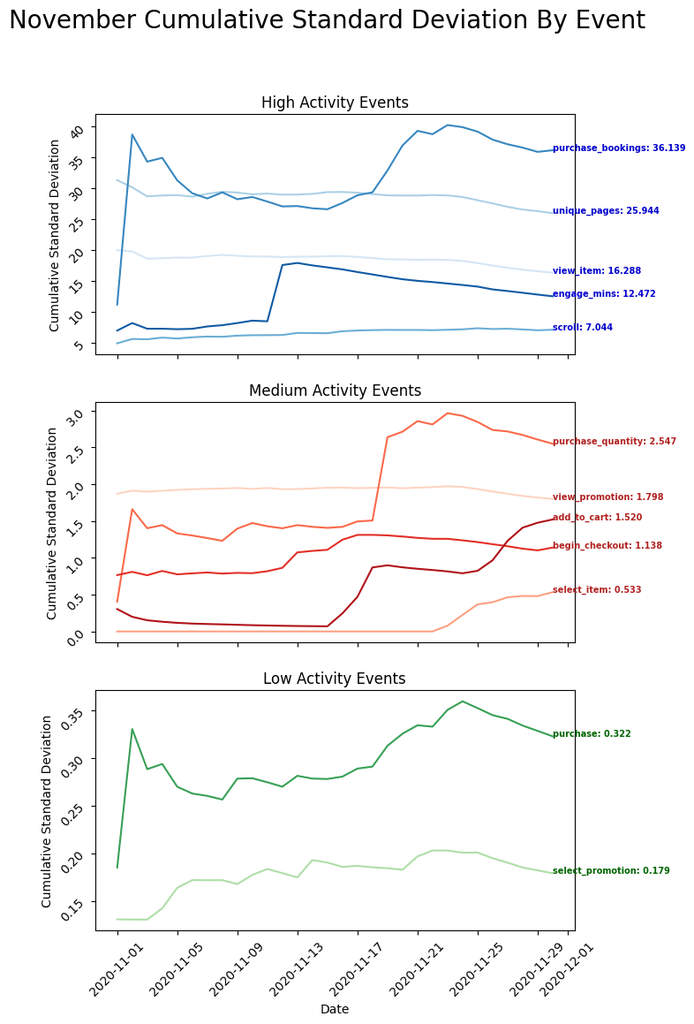

**Conclusions:** Some metrics like purchases (ie orders), purchase quantity(item counts), and bookings had jumps in standard deviations over time. This could be from a number of things.

1. Offering users holiday coupons can cause skewed purchase behavior.
2. The influx of visitors we saw at the end of the month could cause increased volatility. Particularly if it relates to lower/higher than normal quality leads that won't be repeated under normal circumstances.

Big jumps like that are an indicator that the period we are looking at may not be good for estimating normal conditions. Increased variance over time from repeat users should steadily trend upwards not wildly jump.

## D. Confidence Interval Decay over Time Plot

[figure not shown]

**Conclusions:**

b) Since the confidence interval decays faster, if user purchases are the metric of interest, it might be worth considering the use of begin checkout as a primary metric rather than purchase bookings or quantity.

c) **add_to_cart** and **select_item** do not appear to be functioning properly.

**Notes:**

1. **CI_Percent** is the percent error for mean estimates based on confidence intervals. For example, the view_promotion confidence interval was +/- 8% after 30 days.
2. Estimated 95% Two Sided Confidence Intervals were calculated using Welch's Standard Error.

SE = $\sqrt{\frac{S_T^2}{n_T}+\frac{S_C^2}{n_C}} * 1.97$

Daily counts were split in half to represent each group. ie n_c represents half the accrued visitors.

# V. Sample Size Calculations

**Goal:** This section calculates sample size requirements to run an experiment for each metrics and estimates required experiment length to test for a detectable 5%+ effect (MDE). This value is needed for group sequential testing.

**Required n Per Group (n)** = $\frac{(\frac{\alpha}{2}_{crit} + 1-\beta_{crit})^2*2\sigma^2}{\delta^2} $

**where** $\delta$ is the absolute Minimum Detectable Effect size.

The values for $\sigma^2$ and a 5% $\delta$ were calculated from cumulative estimates at the end of the 30 day period from Table C in Section IV(A). Under normal circumstances, this would provide a more conservative estimate incorporating the impact of longer time frames to accrue metrics for some users.

**Note:** 1) Since significant volatilty was present during November, in a real experiment, we would likely pick a different time frame to estimate mean, standard deviation, and sample size. Increased variance leads to higher sample size requirements and uncharacteristically high daily traffic can lead to underestimating duration. However, in this case, this is the only data available from Big Query. 2) I used the absolute difference for MDE in the sample size formula but some fields instruct practitioners to use the standardized difference.

|  | event_name | mean | MDE_5_Percent | CI_Percent | Variance | 90_Power_group_n | DailyVisitors | Est_ExpLength_Days |
| --- | --- | --- | --- | --- | --- | --- | --- | --- |
| post_count | view_promotion | 0.864 | 0.043 | 8.664 | 3.232 | 36431.336 | 295.767 | 246.352 |
| post_count | unique_pages | 12.261 | 0.613 | 8.806 | 673.087 | 37637.461 | 295.767 | 254.508 |
| post_count | scroll | 3.182 | 0.159 | 9.214 | 49.624 | 41203.987 | 295.767 | 278.625 |
| post_count | view_item | 7.124 | 0.356 | 9.515 | 265.298 | 43941.554 | 295.767 | 297.137 |
| post_count | engage_mins | 4.683 | 0.234 | 11.084 | 155.560 | 59631.402 | 295.767 | 403.233 |
| post_count | begin_checkout | 0.328 | 0.016 | 14.434 | 1.296 | 101130.408 | 295.767 | 683.853 |
| post_count | purchase | 0.063 | 0.003 | 21.371 | 0.104 | 221688.115 | 295.767 | 1499.074 |
| post_count | add_to_cart | 0.234 | 0.012 | 27.055 | 2.309 | 355280.284 | 295.767 | 2402.436 |
| post_count | purchase_bookings | 5.244 | 0.262 | 28.677 | 1306.056 | 399178.293 | 295.767 | 2699.278 |
| post_count | select_item | 0.070 | 0.004 | 31.481 | 0.284 | 481027.195 | 295.767 | 3252.748 |
| post_count | select_promotion | 0.022 | 0.001 | 34.039 | 0.032 | 562407.176 | 295.767 | 3803.046 |
| post_count | purchase_quantity | 0.293 | 0.015 | 36.134 | 6.488 | 633751.015 | 295.767 | 4285.480 |

**Conclusions:**

a) Sample size and duration estimates let us know fully running these experiments at a 5% MDE is not practical. In this case, we would have to test for a larger effect size. For the purpose of this example, we will use these estimates in our sequential testing formulas.

b) Below, we will see the danger of running under powered experiments and evaluating too many metrics without using p-valuaes with sequential adjustments.

# VI. Create Experiment Groups

**Goal:** During an A/B test, experiment participants are generally split into treatment and control groups as they arrive. In theory, this reduces group imbalance because one group is less likely to get more users that arrived day 1 than another. To mimic this, I use stratified sampling on first exposure date to create treatment and control groups.

**Step 1:** Use group by to create a table with unique user id and first evaluation page exposure date.

|  | user_pseudo_id | first_exposure_date |
| --- | --- | --- |
| 0 | 7460789402.5841061791 | 2020-11-01 |
| 1 | 3088082.1752157205 | 2020-11-01 |
| 2 | 62488920.2873045428 | 2020-11-01 |
| 3 | 50837037.5294256808 | 2020-11-02 |
| 4 | 3807824.2125956428 | 2020-11-02 |

**Step 2:** Sample 50% of user ids stratified by first experiment exposure date for treatment_status(1) (ie treatment group).

|  | treatment_status | user_pseudo_id |
| --- | --- | --- |
| 1 | 1 | 3088082.1752157205 |
| 2 | 1 | 62488920.2873045428 |
| 3 | 1 | 50837037.5294256808 |
| 7 | 1 | 62738775.4729752170 |
| 8 | 1 | 27433238.8199790608 |

**Step 3:** Merge treatment status with metric table on user id. Convert NaNs to Control(0).

|  | first_exposure_ts | user_pseudo_id | metric_date | adj_event_name | triggered_events | daily_page_visits | daily_calculated_metrics | final_metric_value | first_exposure_date | treatment_status |
| --- | --- | --- | --- | --- | --- | --- | --- | --- | --- | --- |
| 0 | 2020-12-07 16:56:49.353841+00:00 | 8608311.7542015211 | 2020-12-08 | select_promotion | 1 | 0 | NaN | 1.000 | 2020-12-07 | 0 |
| 1 | 2020-11-13 19:30:20.231491+00:00 | 48779096.5110662102 | 2020-12-11 | select_promotion | 1 | 0 | NaN | 1.000 | 2020-11-13 | 1 |
| 2 | 2020-12-10 00:21:11.926568+00:00 | 2685520.9008580684 | 2020-12-10 | select_promotion | 1 | 0 | NaN | 1.000 | 2020-12-10 | 1 |
| 3 | 2020-12-13 10:22:04.834195+00:00 | 5625663904.5035744469 | 2020-12-13 | select_promotion | 1 | 0 | NaN | 1.000 | 2020-12-13 | 1 |
| 4 | 2020-12-02 15:10:32.684709+00:00 | 59367862.5121423398 | 2020-12-02 | select_promotion | 1 | 0 | NaN | 1.000 | 2020-12-02 | 1 |

# VII. Review Metric Distributions

**Goal:** The goal of this section is to review the distribution of our metrics for approximate normality and check if any intesting linear correlations are present between the metrics. For example, we can check if begin_checkout is a good proxy for purchase events by how linearly related they appear.

**Step 1:** Pivot metric table so it is wide. Seaborn pair plot requires a user_id level table.

| adj_event_name | treatment_status | user_pseudo_id | add_to_cart | begin_checkout | engage_mins | purchase | purchase_bookings | purchase_quantity | scroll | select_item | select_promotion | unique_pages | view_item | view_promotion |
| --- | --- | --- | --- | --- | --- | --- | --- | --- | --- | --- | --- | --- | --- | --- |
| 0 | 0 | 10003031.4607645453 | 0.000 | 0.000 | 0.000 | 0.000 | 0.000 | 0.000 | 0.000 | 0.000 | 0.000 | 1.000 | 0.000 | 0.000 |
| 1 | 0 | 1001519.8438987528 | 0.000 | 0.000 | 3.887 | 0.000 | 0.000 | 0.000 | 1.000 | 0.000 | 0.000 | 1.000 | 0.000 | 0.000 |
| 2 | 0 | 10024699.9222099499 | 0.000 | 0.000 | 2.831 | 0.000 | 0.000 | 0.000 | 1.000 | 0.000 | 0.000 | 2.000 | 0.000 | 0.000 |
| 3 | 0 | 1005400.7584979060 | 0.000 | 0.000 | 2.813 | 0.000 | 0.000 | 0.000 | 2.000 | 0.000 | 0.000 | 2.000 | 0.000 | 0.000 |
| 4 | 0 | 1007905.1015859506 | 0.000 | 0.000 | 0.000 | 0.000 | 0.000 | 0.000 | 0.000 | 0.000 | 0.000 | 1.000 | 0.000 | 0.000 |
| ... | ... | ... | ... | ... | ... | ... | ... | ... | ... | ... | ... | ... | ... | ... |
| 9933 | 1 | 9889493649.4111383001 | 0.000 | 0.000 | 0.567 | 0.000 | 0.000 | 0.000 | 0.000 | 0.000 | 0.000 | 1.000 | 1.000 | 0.000 |
| 9934 | 1 | 98961695.3621709069 | 0.000 | 0.000 | 1.595 | 0.000 | 0.000 | 0.000 | 1.000 | 0.000 | 0.000 | 4.000 | 0.000 | 0.000 |
| 9935 | 1 | 99387700.1672480666 | 7.000 | 4.000 | 32.671 | 1.000 | 673.000 | 101.000 | 34.000 | 28.000 | 0.000 | 46.000 | 82.000 | 3.000 |
| 9936 | 1 | 9980503.4644531675 | 0.000 | 0.000 | 0.000 | 0.000 | 0.000 | 0.000 | 0.000 | 0.000 | 0.000 | 1.000 | 0.000 | 0.000 |
| 9937 | 1 | 99874123.0115017691 | 0.000 | 0.000 | 0.191 | 0.000 | 0.000 | 0.000 | 0.000 | 0.000 | 0.000 | 1.000 | 0.000 | 0.000 |

9938 rows × 14 columns

**Step 2:** Create function to add pearsonr to pair plot.

**Source:** https://stackoverflow.com/questions/50832204/show-correlation-values-in-pairplot

**Note:** Function annotates with correlation for each group.

**Step 3:** Since pair plot compares all pairs of metrics, its best to select a few metrics of interest at a time and treatment status.

ie Metrics: engage_mins, purchase_bookings, begin_checkout, scroll, unique_pages, purchase_quantity, add_to_cart.

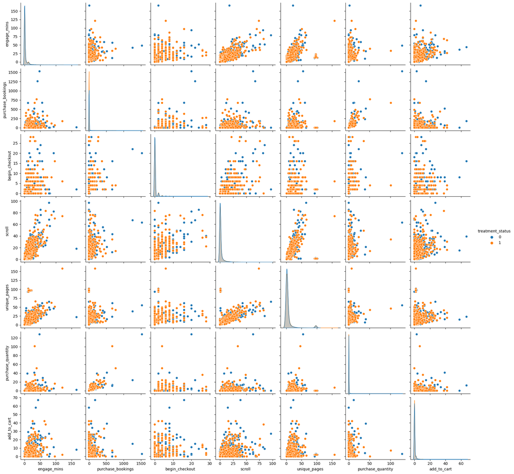

**Conclusion:**

b) **begin_checkout** does not appear linearly related to purchase quantity or purchase amount. Unsurprisingly, starting the checkout process is independent of the quantity of what is in the cart. Since no linear relationship was present, if used as a metric, begin_checkout can probably be a binary variable without losing significant information.

c) We can observe in the data some expected linear relationships. For example, purchase quantity and revenue or unique pages and engagement minutes.

**Note:**

1. If purchase count is extremely important, it would have to be monitored. Although caution must be taken to avoid multiple comparisons, in cases like these, product teams will sometimes include events like purchase count as guardrail metrics to make sure that the purchase flow is functioning.
2. There are many additional factors to consider when choosing an experiment metric. Although purchases seem practical, a product relying on repeat users might prefer longer term oriented metrics like retention. Its important to strategize with product teams when picking a metric.

# VIII. Maximum Sample Size Calculations

**[SECTION UNUSED]**

```
1.959963984540054
```

# IX. Experiment Metrics Calculation

**Goal:** This section aggregates daily, user level treatment/control metrics accrued by visitors after landing on a selected evaluation page over a fake experiment period between 12/1/2020 to 12/14/2020.

Using daily cumulative statistics, daily p-values are plotted for each metric using a traditional t-test method versus a sequential method (O'Brien Fleming two sided spending function).

$\alpha' = 2 * (1- \Phi (\frac{\phi^{-1}(1-\alpha/2)}{\sqrt{t}}) )$ = $2 * (1- \Phi (\frac{1.96}{\sqrt{t}}) )$ **One Sided**

**where** t is the fraction completed. ie .8 for 80%

Given no real experiment was run, we'd expect all p-values to be insignificant. However, because we have multiple comparisons and end tests long before recommended, the ttest method gives us a number of false postivies.

**Step 1:** Create a list of experiment metrics to be evaluated.

```
['purchase_bookings',
 'begin_checkout',
 'scroll',
 'view_item',
 'engage_mins',
 'purchase',
 'add_to_cart',
 'purchase_quantity',
 'unique_pages',
 'view_promotion',
 'select_item',
 'select_promotion']
```

**Step 2:** Create a list of all unique dates for evaluation.

```
[Timestamp('2020-12-03 00:00:00'),
 Timestamp('2020-12-02 00:00:00'),
 Timestamp('2020-12-13 00:00:00'),
 Timestamp('2020-12-08 00:00:00'),
 Timestamp('2020-12-01 00:00:00')]
```

**Step 3:** Loop through daily_activity_df and calculate per user metrics for each event accruing prior to reference date. ie Post Visit Scrolls Per Visitor.

## A. Steps to Calculate Experiment Metric Summary Statistics

1. The **first for loop** creates a dataframe with all unique experiment participant **user ids** appearing on(or before) the reference date (i) and assigns a 0 to each user_id in a column called **post_count**.
2. The **second for loop** creates a dataframe with **user_id** and triggered_events counts as **post_count** for each **adj_event_name(j) in event_array** on(or before) the reference date (i).
3. **User Level Aggregation**: The dataframe from the first loop is concatinated with the dataframe from the second and **post_count is summed to the user level.** Note: Summing drops 0 values for users that triggered the selected event but keeps those who did not.
4. Calculate Statistics

**Step 4:** Merge treatment and control calculated stats into a single wide table.

**Step 5:** Creates days since experiment start column by subtracting min reference date from reference dates.

```
Timestamp('2020-12-01 00:00:00')
```

**Step 6:** Calculate adjusted O'Brien Fleming alpha thresholds.

|  | reference_date | event_name | mean_t | mean_c | std_t | std_c | count_t | count_c | p_value_t | days_rqd_t | group_diff | Days_Since_Start | proportion_complete | OF_seq_p |
| --- | --- | --- | --- | --- | --- | --- | --- | --- | --- | --- | --- | --- | --- | --- |
| 13 | 2020-12-14 | view_promotion | 0.495 | 0.434 | 1.433 | 1.405 | 4969.000 | 4969.000 | 0.033 | 246.352 | 0.061 | 13.000 | 0.057 | 0.000 |
| 27 | 2020-12-14 | view_item | 3.507 | 3.078 | 11.455 | 9.844 | 4969.000 | 4969.000 | 0.046 | 297.137 | 0.428 | 13.000 | 0.047 | 0.000 |
| 41 | 2020-12-14 | unique_pages | 6.717 | 6.002 | 18.429 | 17.013 | 4969.000 | 4969.000 | 0.045 | 254.508 | 0.715 | 13.000 | 0.055 | 0.000 |
| 55 | 2020-12-14 | select_promotion | 0.018 | 0.011 | 0.159 | 0.122 | 4969.000 | 4969.000 | 0.028 | 3803.046 | 0.006 | 13.000 | 0.004 | 0.000 |
| 69 | 2020-12-14 | select_item | 0.312 | 0.264 | 1.452 | 1.142 | 4969.000 | 4969.000 | 0.070 | 3252.748 | 0.047 | 13.000 | 0.004 | 0.000 |
| 83 | 2020-12-14 | scroll | 2.092 | 1.876 | 5.985 | 5.749 | 4969.000 | 4969.000 | 0.067 | 278.625 | 0.215 | 13.000 | 0.050 | 0.000 |
| 97 | 2020-12-14 | purchase_quantity | 0.219 | 0.180 | 2.130 | 2.246 | 4969.000 | 4969.000 | 0.381 | 4285.480 | 0.038 | 13.000 | 0.003 | 0.000 |
| 111 | 2020-12-14 | purchase_bookings | 3.689 | 3.526 | 28.232 | 37.354 | 4969.000 | 4969.000 | 0.806 | 2699.278 | 0.163 | 13.000 | 0.005 | 0.000 |
| 125 | 2020-12-14 | purchase | 0.046 | 0.043 | 0.276 | 0.256 | 4969.000 | 4969.000 | 0.497 | 1499.074 | 0.004 | 13.000 | 0.009 | 0.000 |
| 139 | 2020-12-14 | engage_mins | 2.718 | 2.408 | 7.025 | 6.758 | 4969.000 | 4969.000 | 0.025 | 403.233 | 0.310 | 13.000 | 0.035 | 0.000 |
| 153 | 2020-12-14 | begin_checkout | 0.324 | 0.308 | 1.487 | 1.479 | 4969.000 | 4969.000 | 0.588 | 683.853 | 0.016 | 13.000 | 0.020 | 0.000 |
| 167 | 2020-12-14 | add_to_cart | 0.563 | 0.531 | 2.484 | 2.653 | 4969.000 | 4969.000 | 0.537 | 2402.436 | 0.032 | 13.000 | 0.006 | 0.000 |

**Table E Description:** Table includes daily accrued summary statistics for treatment and control groups by metric. ie. mean, standard deviation(**std**), sample size count(**count**), the difference between group means(**group_diff**), t-test p_values for the difference (**p_value_t**), days since experiment start(**Days_Since_Start**), days required for experiment by sample size calculations (**days_rqd**), proportion of required days complete (**proportion_complete**), and the O'Brien Fleming adjusted p-value threshold (**OF_seq_p**).

**Note:** This experiment is so underpowered that the OF_seq_p is 0.

## B. Unadjusted T-Test P-Values Over Time Plot

**Goal:** Plotting daily p-values allows us to observe the amount of fluctuation early on and our risk of false positives from too many metrics.

[figure not shown]

**Conclusion:** Despite knowing metrics should not have statistically significant differences, we see numerous metrics are false positives. This is because we are evaluating too many metrics with too little sample size. This would have been avoided had we used O'Brien Flemming thresholds.

**Notes:**

1. Estimated 95% Two Sided Confidence Intervals were calculated using Welch's Standard Error.

SE = $\sqrt{\frac{S_T^2}{n_T}+\frac{S_C^2}{n_C}} * 1.97$

Daily counts were split in half to represent each group. ie n_c represents half the accrued visitors.

2. Add experiment groups and calculate P-Values.

## C. P-Values with Estimated Treatment Effect Plot

**Goal:** This plot allows views estimated effect sizes for false positives at the end of the period.

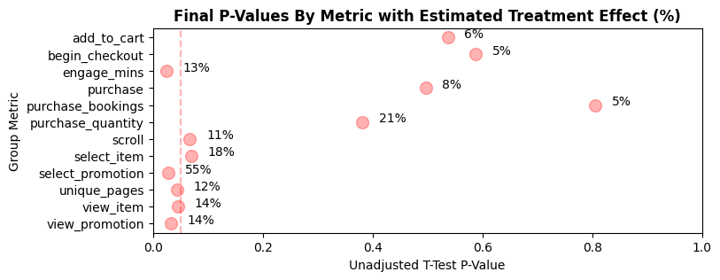

**Conclusion:** Despite there being no real difference, at small sample sizes, some of the metrics show some pretty large false postive effects.

**Note:** It is possibile **select_promotion** promotion is likely not functioning.

# X. Single Metric Repeated Draws ~ T-Test P-Value Over Time

## A. Create Dataframe with Different Treatment and Control Group Designations

**Goal:** This section repeatedly redefines which visitors are in treatment and control groups and calculates summary stats and p-values for each grouping over time for a selected metric.

## B. Plot P-Values Over Time for Each Draw

[figure not shown]

## C. Plot Distribution of P-Values for Each Draw and Average False Positive Difference

```
Average False Positive Difference: 17 %
False Positive Rate: 4 %
```

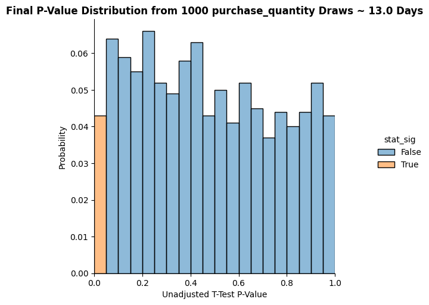

**Note:** The plot below shows how the likelihood of a false positive grows as more and more tests are run using a geometric cdf. ie Geom(p=.05) A large false positive effect size becomes likley sooner than we'd expect when many underpowered tests are run.

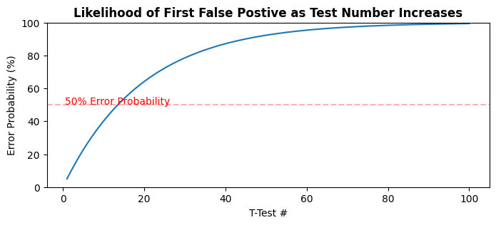

# XI. Appendix - Sequential Testing Methods

## A. Group Sequential Testing

**Source:** Group Sequential Methods with Applications to Clinical Trials (Turnbull et al.)

**Notes:** 1) Some sources claim group sequential testing can hurt power. Ability to detect no change.

*Group sequential designs have been developed to efficiently test hypotheses using the Neyman-Pearson approach for statistical inference, where the goal is to decide how to act, while controlling error rates in the long run. Group sequential designs do not have the goal to quantify the strength of evidence, or provide accurate estimates of the effect size (Proschan et al., 2006).* **Group Sequential Designs (Lakens) at 9.**

2. Some sources discuss using stagewise means and standard deviations in each calculation rather than the cumulative. ie Only the new experiment participants during the period. Probably to keep variance stable across groups. See rpact https://www.rpact.org/vignettes/getting-started/rpact_step-by-step_tutorial/

**Next Steps:**

Think about whether controlling for cumulative variance becoming larger over time due to earlier participants having more time to accrue outcomes is necessary? Uber uses a method called delete-a-group jackknife variance estimation to adjust for user correlation across multiple days.

### i. Pocock's Test

#### a) Adjusted Critical Values

$Z_k = \frac{1}{\sqrt{2mK \sigma^2 }} ( \sum_{i=1}^{mk}X_A - \sum_{i=1}^{mk}X_B)$

Where m is group size and k is the number of groups. k is chosen before experiment start.

**Adjusted Critical Values** are based on the # of checkins and chosen sinificance level (a)

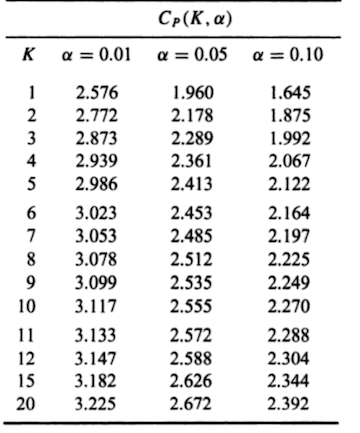

#### b) Adjusted Alphas

**Adjusted Alpha Threshold:**

$\alpha' = 2 * (1- \Phi (AdjustedCriticalValue))$

#### Example: P-Value Threshold

**K** = 5 and $\alpha$=.05

**Adjusted Critical Value** = 2.413 based on chart above.

```
0.015821819570605467
```

#### c) Maximum Sample Size (Inflation Factors)

Required sample size(n) for test needs to be scaled up by a ratio Rp($ K, \beta, \alpha$) * $n_{group}$

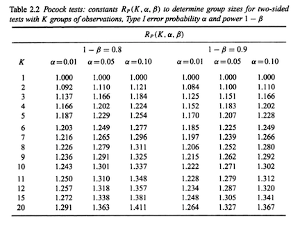

#### - Sample Size Notation / Formulas for Example Calculation:

**Required n Per Group (n)** = $\frac{(\frac{\alpha}{2}_{crit} + 1-\beta_{crit})^2*2\sigma^2}{\delta^2} $

**Note:** *Percent point function (inverse of cdf — percentiles).*

$\alpha_{crit95} = \phi^{-1}(.975)$ = norm.ppf(.975, loc=0, scale=1) = 1.96

$1-\beta_{crit90} = \phi^{-1}(.9)$ = norm.ppf(.9, loc=0, scale=1) = 1.28

**$\sigma^2$** = 4 , **MDE($\delta$)** = 1 , **K** = 5

```
The test stops at 102 participants per group and evaluation can occur every m = 21 participants.
```

#### d) Stopping Rule (Reject Null if)

$\mid \sum_{i=1}^{mk}X_A - \sum_{i=1}^{mk}X_B \mid$ $\geq adj_{crit}(2.413)* \sqrt{2*n_{group}\sigma^2}$

**Note:** The enhanced critical value remains constant over each stop.

If not rejected by the K stop, the null wins.

### ii. O'Brien & Fleming's Test

#### a) Adjusted Critical Values

This test does not have constant critical values. Constant critical values are adjusted by a formula that depends on which K you are on.

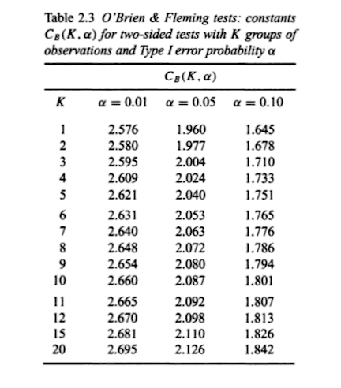

$ crit_k = C_{const}*\sqrt{ \frac{K_{total}}{k_{stop} }} $

**Example:**

k = 2. ie Second Evaluation Stops

K = 5. ie 5 Total Evaluations

alpha = .05

```
3.2255232133717473
```

#### b) Adjusted Alpha

**Adjusted Alpha Threshold:**

$\alpha' = 2 * (1- \Phi (AdjustedCriticalValue*\sqrt{ \frac{K_{total}}{k_{stop} }}) )$

**Adjusted Critical Values** are based on total check ins(K), the check in number(k) ie first check in k=1, and chosen sinificance level (a)

**Example (cont...):**

k = 2. ie Second Evaluation Stops

K = 5. ie 5 Total Evaluations

```
0.001257426382596627
```

#### c) Maximum Sample Size (Inflation Factors)

Required sample size(n) for test needs to be scaled up by a ratio Rp($ K, \beta, \alpha$) * $n_{group}$

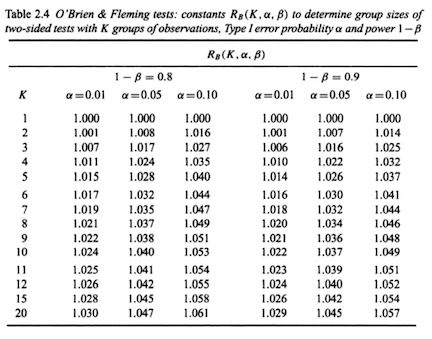

```
The test stops at 87 participants per group and evaluation can occur every m = 18 participants.
```

#### d) Stopping Rule (Reject Null if)

$\mid \sum_{i=1}^{mk}X_A - \sum_{i=1}^{mk}X_B \mid$ $\geq crit_{AdjConst}(2.040)*\sqrt{5/k_{stop}}*\sqrt{2*n_{group}\sigma^2}$

**Notes:** 1)The enhanced critical value changes by a factor of $\sqrt{K_{Total}/k_{stop}}$ for each stop.

2)If not rejected by the K stop, the null wins. 3) $ 2*n_{group} $ assumes equal group sizes. 4)Equation shifts $ \sqrt{2*n_{group}\sigma^2} $ to the right instead of keeping it in the left side denominator.

## B. Georgiev Sequential $Z_k$ Score and Alpha Spending Functions

### i. Critical Value at Time k of K

Georgiev at 165

$Z_k = \frac{ \sum_{i=1}^{n_k}(X_i -Y_i) }{\sqrt{(2*n_{k}\sigma^2})}$

### iii. O'Brien Fleming like (Georgiev)

Georgiev at 169.

**a) Adjusted Alpha Threshold:**

$\alpha' = 2 * (1- \Phi (\frac{CriticalValue}{\sqrt{t}}) )$

**where** t is the fraction completed. ie .8 for 80%

```
0.028426718949041252
```

### iv. O'Brien Fleming like (DeMets)

**a) Adjusted Alpha Threshold:**

$\alpha' = 2 * (1- \Phi (\frac{\phi^{-1}(1-\alpha/2)}{\sqrt{t}}) )$ One Sided (Georgiev Version)

$\alpha' = 4 * (1- \Phi (\frac{\phi^{-1}(1-\alpha/4)}{\sqrt{t}}) )$ Two Sided

**where** t is the fraction completed. ie .8 for 80%

**Notes:** Requires equally spaced looks. No requirement that number or timing of looks specified in advance. **However, decision to implement should not be based on results.**

#### b) O'Brien Fleming like Spending Function Plots (Georgiev)

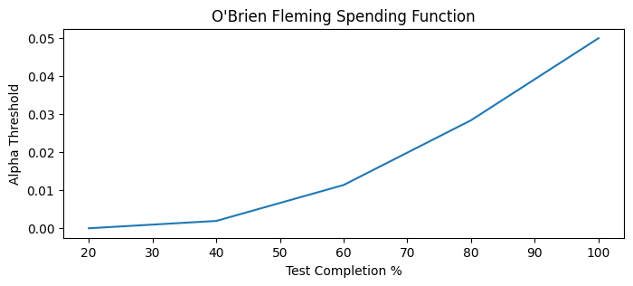

### v. Kim & DeMets Power Family

**a) Adjusted Alpha Threshold:**

$\alpha' = \alpha * t^\rho$

**where** $\rho$ is generally between 0 and 3 selected by the tester and t is the fraction completed. ie .8 for 80%.

**rho notes:** The value of rho ranges from 0 to 3. 3 resembles O'Brien Fleming test. 1 is uniform. 1.5 falls in the middle. Under 1 allows stopping very early. A high rho penalizes early test results more. Stopping too early leads to greater bias in point estimates. This is known as conditional bias. See Maximum Conditional Likelihood Estimates by DeMets. https://journals.sagepub.com/doi/10.1177/09622802221122445 See also DeMets Restricted Conditional Confidence Interval and Exact Conditional Confidence Intervals.

```
0.025600000000000008
```

#### b) Kim & DeMets Spending Function Plot ( $\rho$ = 3)

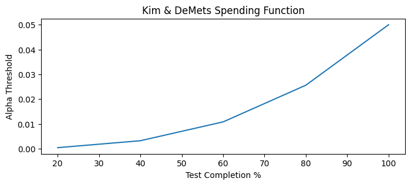

## C. Sequential Testing - Always Valid P-Values

## i. mSPRT (Optimizely Version)

Always Valid p-values

**Source:** Peeking at A/B Tests (Johari et al)

## Formulas / Notation (Mixture Likelihood Ratios)

$\Lambda_n^{H,\theta_0}$ = $\sqrt{ \frac{2\sigma^2}{2\sigma^2 + n\tau^2}}* exp(\frac{n^2\tau^2(\bar Y_n- \bar X_n-\theta_0)^2}{4\sigma^2(2\sigma^2 + n\tau^2)})$

where

$\theta_0$ is the difference of the null hypothesis and $\tau^2$ is the variance of the mixing distribution.

**Mixing Distribution(H):** $H$ ~ $N(\theta_0, \tau^2)$

**Note:** The mixing distribution H should match the distribution of true effects across prior experiments. 1 discussed for rate in paper. In a recent paper, Kohavi et al. gives experiment success rates between 8 to 33%.

**Source:** [A/B Testing Intuition Busters (Kohavi et al.)](https://exp-platform.com/abtestingintuitionbusters/)

## ii. Eppo Version (NOT FUNCTIONING)

**Source:** Time-uniform, nonparametric, nonasymtotic confidence sequences (Howard et al)

https://docs.geteppo.com/statistics/confidence-intervals/statistical-nitty-gritty

```
0.12886938700297645
```

```
0.0037335224808904784
```

```
Eppo CI 12.876% and 12.898% Lift ]
Mean(%): 12.887%
```

## iii. Growth Book Version

**Source:** https://docs.growthbook.io/statistics/sequential

**Note:** Claims to be the same as Spotify article. https://engineering.atspotify.com/2023/03/choosing-sequential-testing-framework-comparisons-and-discussions/

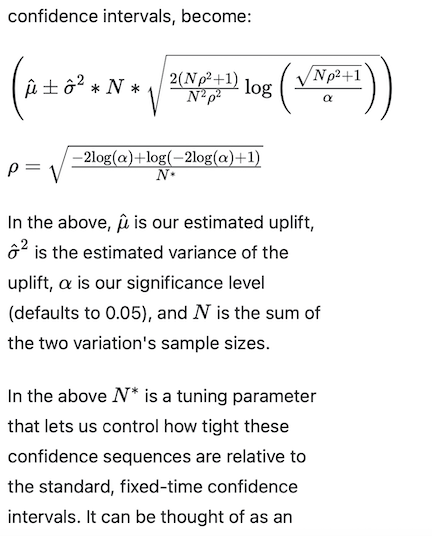

```
Spotify CI 0.00 and 0.00
Mean: 0.00
```